# network visualiser

13/07/2019

## Network Visualiser

This shiny app generates a network graph based on various input parameters.

The app:

- Generates a random set of edges
- Calculates the weight of each edge (based on the count of edges with the same source/destination)
- Creates a tidy graph object from these edges
- Plots the graph using ggplot with various graphical parameters based on user input
- Calculates the shortest path between 2 points chosen by the user

## User Input

Check boxes, selectors and textbox inputs allow the user to:

- Set the number of vertices
- Set the number of edges
- Set start and end node for shortest path calculation
- Show/hide vertices
- Show/hide vertex labels
- Scale edge width according to the edge weight (number of edges between 2 vertices)
- Change the type of edge (arcs or straight lines)
- Change the colour of edges/vertices/labels

## Simple Network Graph

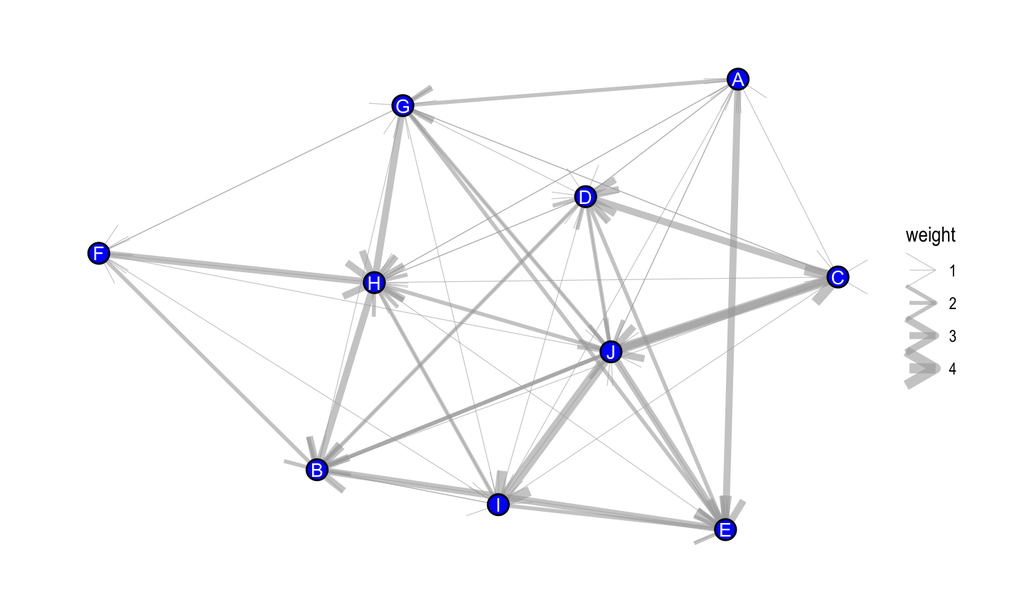

```
## shortest path from A to F is:  A H F
```

## Dependencies and Additional Reading

The app uses: ggplot2, ggraph, shiny, tidygraph, tidyverse

For more information about network graph visualisations and tidygraph check out:

- [Intro to tidygraph](https://www.data-imaginist.com/2017/introducing-tidygraph/)
- [Network analysis with R](https://www.jessesadler.com/post/network-analysis-with-r/)
- [Static and dynamic network visualization with R](http://kateto.net/network-visualization)